# Mapping Revitalization in Buffalo, NY, through Income, Vacancy and Demographic Makeup Data from 2013 to 2015

Shengyuan Zou

Dec 7, 2017

# Introduction

In 2010, Buffalo Mayor Byron Brown announced revitalization plan for City of Buffalo, including Demolition plan in 2007, Regional Action Plan for Downtown, Commercial Area Revitalization Effort (CARE) Program revitalization plans, the Local Waterfront Revitalization Program, the Buffalo Niagara Medical Campus Master Plan, plans created through the Good Neighbors Planning Alliance and others. (Buffalo Comprehensive Plan). Mapping the social variables provides us a quantitative way to measure and understand the revitalization progress and its spatial and temporal characteristics. The changes are visible in recent years. New medical center is built up in downtown, and more than 4,000 vacant houses have been demolished since 2007. Since these policies are pushed and implemented, it is very interesting to explore the feedback of social variables in local society. This project explores the feedback at a very start stage from economic, housing and demographic makeup aspects. The change in income, housing vacancy and race from 2013 to 2015 represent how the implementation of policies affects local society in the beginning.

The objective of this project is to map the changes of these demographical variables in Buffalo, Erie County from block-group-level census data from 2013 to 2015.

# Data

The geometry data are block-group-level shapfile for Erie County in 2015, which is downloaded from TIGER 029 at the block group level for Erie County using tigris package. A similar research has been done at the census tract level to explore the relationship between vacancy and other social variables in Buffalo on 2008-2010, before revitalization (Silverman et al. 2012).

Data availability

The demographic data, vacancy status, median household income and total population in race data in 2013, 2014 and 2015 are downloaded from census website. The CensusAPI has been tried. But block-group-level occupancy data is not accessible. Thus, we have to download these data from census wibsite manually. In addition, occupancy status data, which is estimated by the American Community Survey program, are only available from 2013 to 2015.

```r
shpfile<-block_groups('NY',county='Erie',year='2015')
#plot(shpfile,col=1:100)
```

```r
Income2013=read.csv(file = 'Data/Income2013.csv')

Income2014=read.csv(file = 'Data/Income2014.csv')

Income2015=read.csv(file = 'Data/Income2015.csv')

VR2013=read.csv(file = 'Data/VacancyRate2013.csv')

VR2014=read.csv(file = 'Data/VacancyRate2014.csv')

VR2015=read.csv(file = 'Data/VacancyRate2015.csv')

Race2013=read.csv(file = 'Data/RaceRatio2013.csv')

Race2014=read.csv(file = 'Data/RaceRatio2014.csv')

Race2015=read.csv(file = 'Data/RaceRatio2015.csv')
```

# Method

1.Variable calculation

Vacancy rate=#Vacant house/#Total house

Race ratio=#White population/#Total population

Income=Median household income

2.Change calculation

Calculate the difference between individual years by joinging tables and subtracting previous year value.

```r
Income1=merge(Income2013,Income2014,by.x = 'GEO.id2',by.y = 'GEO.id2')

Income1$Change1=as.numeric(Income1$HD01_VD01.y)-as.numeric(Income1$HD01_VD01.x)

Income2=merge(Income2014,Income2015,by.x = 'GEO.id2',by.y = 'GEO.id2')

Income2$Change2=as.numeric(Income2$HD01_VD01.y)-as.numeric(Income2$HD01_VD01.x)

VR1=merge(VR2013,VR2014,by.x = 'GEO.id2',by.y = 'GEO.id2')

VR1$Change1=as.numeric(VR1$HD01_VD03.y)/as.numeric(VR1$HD01_VD01.y)-as.numeric(VR1$HD01_VD03.x)/as.numeric(VR1$HD01_VD01.x)

VR2=merge(VR2014,VR2015,by.x = 'GEO.id2',by.y = 'GEO.id2')

VR2$Change2=as.numeric(VR2$HD01_VD03.y)/as.numeric(VR2$HD01_VD01.y)-as.numeric(VR2$HD01_VD03.x)/as.numeric(VR2$HD01_VD01.x)


Race1=merge(Race2013,Race2014,by.x = 'GEO.id2',by.y = 'GEO.id2')

Race1$Change1=as.numeric(Race1$HD01_VD02.y)/as.numeric(Race1$HD01_VD01.y)-as.numeric(Race1$HD01_VD02.x)/as.numeric(Race1$HD01_VD01.x)

Race2=merge(Race2014,Race2015,by.x = 'GEO.id2',by.y = 'GEO.id2')

Race2$Change2=as.numeric(Race2$HD01_VD02.y)/as.numeric(Race2$HD01_VD01.y)-as.numeric(Race2$HD01_VD02.x)/as.numeric(Race2$HD01_VD01.x)
```

# Results and Visualization

```r
Income1_Join=geo_join(shpfile,Income1,'GEOID','GEO.id2',how='inner')
Income2_Join=geo_join(shpfile,Income2,'GEOID','GEO.id2',how='inner')
VR1_Join=geo_join(shpfile,VR1,'GEOID','GEO.id2',how='inner')
VR2_Join=geo_join(shpfile,VR2,'GEOID','GEO.id2',how='inner')
Race1_Join=geo_join(shpfile,Race1,'GEOID','GEO.id2',how='inner')
Race2_Join=geo_join(shpfile,Race2,'GEOID','GEO.id2',how='inner')
```

```r
#Visualize the change in house vacancy, income and demographic made up

#Income change from 2013-2014
summary(Income1_Join$Change1)
```

```
##      Min.   1st Qu.    Median      Mean   3rd Qu.      Max.
## -735.0000  -22.0000    5.0000   -0.2157   31.0000  729.0000
```

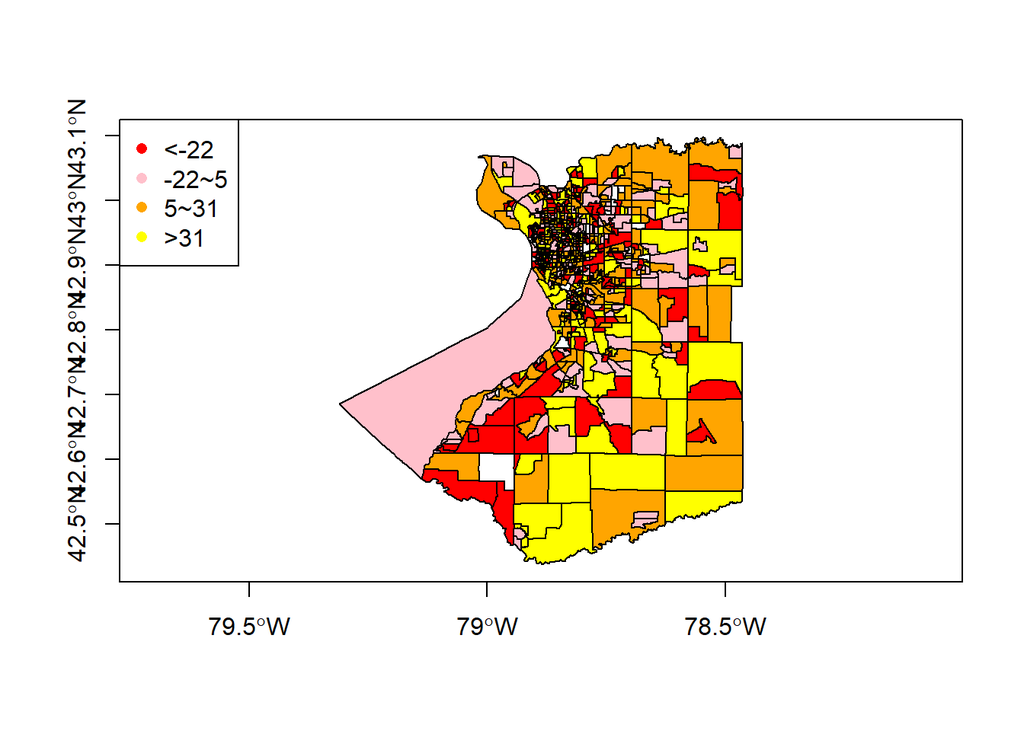

```r
Income1_Join$color=NULL
Income1_Join$color[Income1_Join$Change1< -22]='red'
Income1_Join$color[Income1_Join$Change1>-22&Income1_Join$Change1<5]='pink'
Income1_Join$color[Income1_Join$Change1>5&Income1_Join$Change1<31]='orange'
Income1_Join$color[Income1_Join$Change1>31]='yellow'

plot(Income1_Join,axes=TRUE,col=Income1_Join$color)
legend(x='topleft', legend=c("<-22","-22~5","5~31",">31"), col=c("red","pink","orange","yellow"),pch=16)
```

```r
#Income change from 2014-2015
summary(Income2_Join$Change2)
```

```
##     Min.  1st Qu.   Median     Mean  3rd Qu.     Max.
## -742.000  -40.000  -10.000   -8.681   14.000  722.000
```

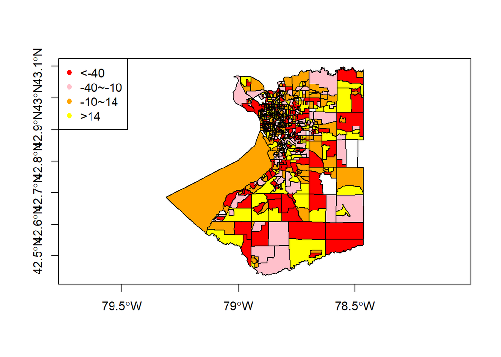

```r
Income2_Join$color=NULL
Income2_Join$color[Income2_Join$Change2< -40]='red'
Income2_Join$color[Income2_Join$Change2>-40&Income2_Join$Change2< -10]='pink'
Income2_Join$color[Income2_Join$Change2>-10&Income2_Join$Change2<14]='orange'
Income2_Join$color[Income2_Join$Change2>14]='yellow'

plot(Income2_Join,axes=TRUE,col=Income2_Join$color)
legend(x='topleft', legend=c("<-40","-40~-10","-10~14",">14"), col=c("red","pink","orange","yellow"),pch=16)
```

```r
#Vacancy rate change from 2013-2014

summary(VR1_Join$Change1)
```

```
##      Min.   1st Qu.    Median      Mean   3rd Qu.      Max.
## -50.32633  -0.06932  -0.00019  -0.02685   0.04833  68.05556
```

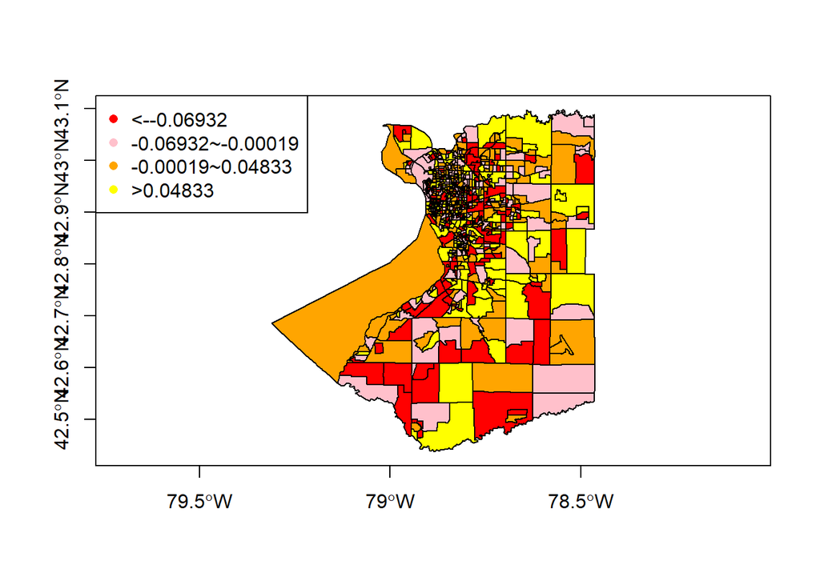

```r
VR1_Join$color=NULL
VR1_Join$color[VR1_Join$Change1< -0.06932]='red'
VR1_Join$color[VR1_Join$Change1>-0.06932&VR1_Join$Change1< -0.00019]='pink'
VR1_Join$color[VR1_Join$Change1>-0.00019&VR1_Join$Change1<0.04833]='orange'
VR1_Join$color[VR1_Join$Change1>0.04833]='yellow'

plot(VR1_Join,axes=TRUE,col=VR1_Join$color)
legend(x='topleft', legend=c("<--0.06932","-0.06932~-0.00019","-0.00019~0.04833",">0.04833"), col=c("red","pink","orange","yellow"),pch=16)
```

```r
#Vacancy rate change from 2014-2015
summary(VR2_Join$Change2)
```

```
##      Min.   1st Qu.    Median      Mean   3rd Qu.      Max.
## -48.83333  -0.07938  -0.00128  -0.02393   0.03035  71.33333
```

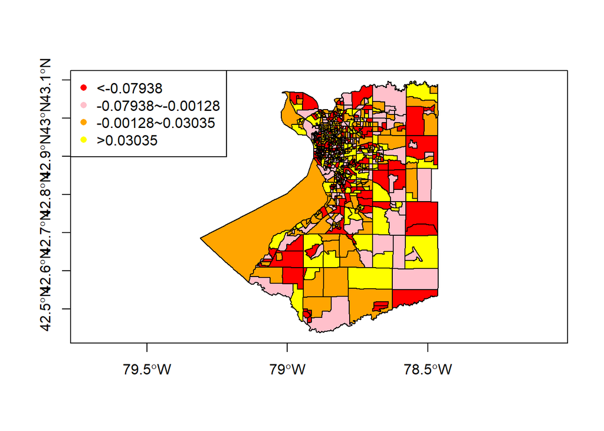

```r
VR2_Join$color=NULL
VR2_Join$color[VR2_Join$Change2< -0.07938]='red'
VR2_Join$color[VR2_Join$Change2>-0.07938&VR2_Join$Change2< -0.00128]='pink'
VR2_Join$color[VR2_Join$Change2>-0.00128&VR2_Join$Change2<0.03035]='orange'
VR2_Join$color[VR2_Join$Change2>0.03035]='yellow'

plot(VR2_Join,axes=TRUE,col=VR2_Join$color)
legend(x='topleft', legend=c("<-0.07938","-0.07938~-0.00128","-0.00128~0.03035",">0.03035"), col=c("red","pink","orange","yellow"),pch=16)
```

```r
#Race ratio change from 2013-2014
summary(Race1_Join$Change1)
```

```
##       Min.    1st Qu.     Median       Mean    3rd Qu.       Max.
## -204.56364   -0.07341   -0.01908   -0.34814    0.02368  190.67568
```

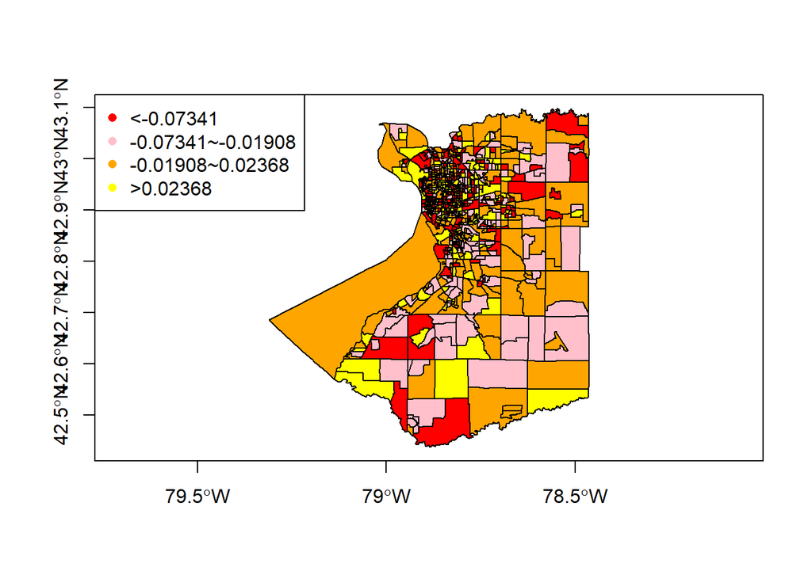

```r
Race1_Join$color=NULL
Race1_Join$color[Race1_Join$Change1< -0.07341]='red'
Race1_Join$color[Race1_Join$Change1>-0.07341&Race1_Join$Change1< -0.01908]='pink'
Race1_Join$color[Race1_Join$Change1>-0.01908&Race1_Join$Change1<0.02368]='orange'
Race1_Join$color[Race1_Join$Change1>0.02368]='yellow'

plot(Race1_Join,axes=TRUE,col=Race1_Join$color)
legend(x='topleft', legend=c("<-0.07341","-0.07341~-0.01908","-0.01908~0.02368",">0.02368"), col=c("red","pink","orange","yellow"),pch=16)
```

```r
# Race ratio change from 2014-2015
summary(Race2_Join$Change2)
```

```
##       Min.    1st Qu.     Median       Mean    3rd Qu.       Max.
## -190.11129   -0.08153   -0.01565    0.77929    0.02732  313.05333
```

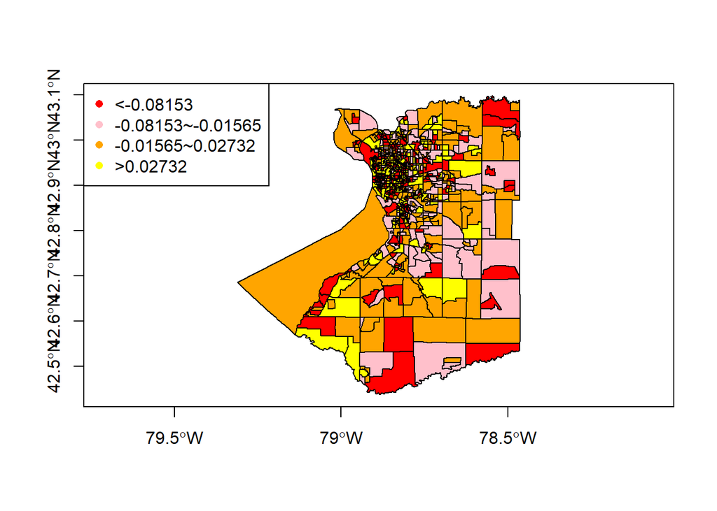

```r
Race2_Join$color=NULL
Race2_Join$color[Race2_Join$Change2< -0.08153]='red'
Race2_Join$color[Race2_Join$Change2>-0.08153&Race2_Join$Change2< -0.01565]='pink'
Race2_Join$color[Race2_Join$Change2>-0.01565&Race2_Join$Change2<0.02732]='orange'
Race2_Join$color[Race2_Join$Change2>0.02732]='yellow'

plot(Race2_Join,axes=TRUE,col=Race2_Join$color)
legend(x='topleft', legend=c("<-0.08153","-0.08153~-0.01565","-0.01565~0.02732",">0.02732"), col=c("red","pink","orange","yellow"),pch=16)
```

Merge two years change and summarize

```r
Income_Total=inner_join(Income1,Income2,by="GEO.id2")
Income_Total$ChangeInTwoYears<-Income_Total$Change1+Income_Total$Change2
summary(Income_Total$ChangeInTwoYears)
```

```
##     Min.  1st Qu.   Median     Mean  3rd Qu.     Max.
## -739.000  -49.250   -3.000   -8.615   38.000  721.000
```

```r
VR_Total=inner_join(VR1,VR2,by="GEO.id2")
VR_Total$ChangeInTwoYears<-VR_Total$Change1+VR_Total$Change2
summary(VR_Total$ChangeInTwoYears)
```

```
##      Min.   1st Qu.    Median      Mean   3rd Qu.      Max.
## -50.38641  -0.15818  -0.00109  -0.05073   0.08696  71.42857
```

```r
Race_Total=inner_join(Race1,Race2,by="GEO.id2")
Race_Total$ChangeInTwoYears<-Race_Total$Change1+Race_Total$Change2
summary(Race_Total$ChangeInTwoYears)
```

```
##       Min.    1st Qu.     Median       Mean    3rd Qu.       Max.
## -160.96528   -0.13716   -0.03448    0.43058    0.03833  312.98869
```

# Correlation analysis

```r
#Pearson's Correlation coefficient
#Join all 2year change

Change_Join=merge(Income_Total,VR_Total,by="GEO.id2")
Change_Join_All=merge(Change_Join,Race_Total,by="GEO.id2")
head(Change_Join_All)
```

[output not shown]

[output cut: 153 more lines]

```r
Change_Income=Change_Join_All$ChangeInTwoYears.x
Change_VR=Change_Join_All$ChangeInTwoYears.y
Change_Race=Change_Join_All$ChangeInTwoYears
#cor between vr and income
cor.test(Change_Income,Change_VR)
```

```
##
##  Pearson's product-moment correlation
##
## data:  Change_Income and Change_VR
## t = 0.019741, df = 766, p-value = 0.9843
## alternative hypothesis: true correlation is not equal to 0
## 95 percent confidence interval:
##  -0.07003455  0.07145393
## sample estimates:
##          cor
## 0.0007132599
```

```r
cor.test(Change_Income,Change_Race)
```

```
##
##  Pearson's product-moment correlation
##
## data:  Change_Income and Change_Race
## t = -1.1066, df = 766, p-value = 0.2688
## alternative hypothesis: true correlation is not equal to 0
## 95 percent confidence interval:
##  -0.11038476  0.03087907
## sample estimates:
##         cor
## -0.03995248
```

```r
cor.test(Change_Race,Change_VR)
```

```
##
##  Pearson's product-moment correlation
##
## data:  Change_Race and Change_VR
## t = -0.081342, df = 766, p-value = 0.9352
## alternative hypothesis: true correlation is not equal to 0
## 95 percent confidence interval:
##  -0.07366796  0.06781937
## sample estimates:
##       cor
## -0.002939
```

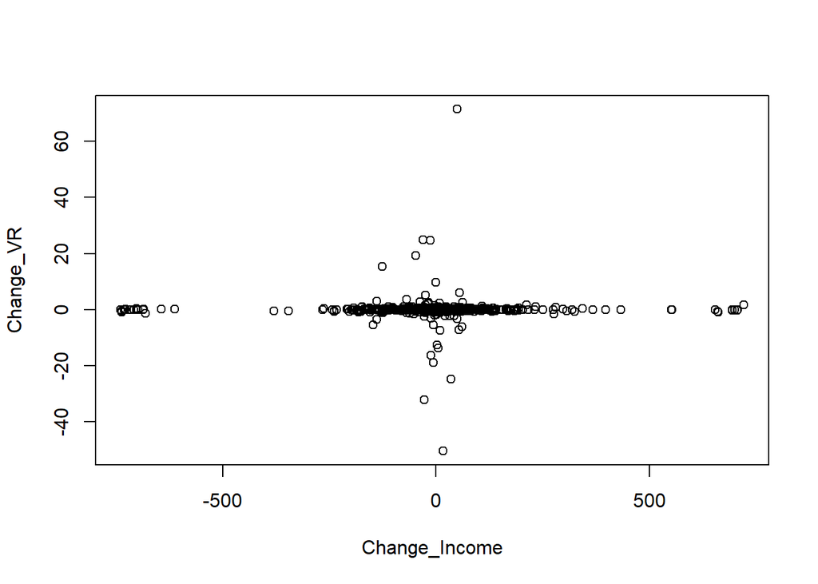

```r
plot(Change_Income,Change_VR)
```

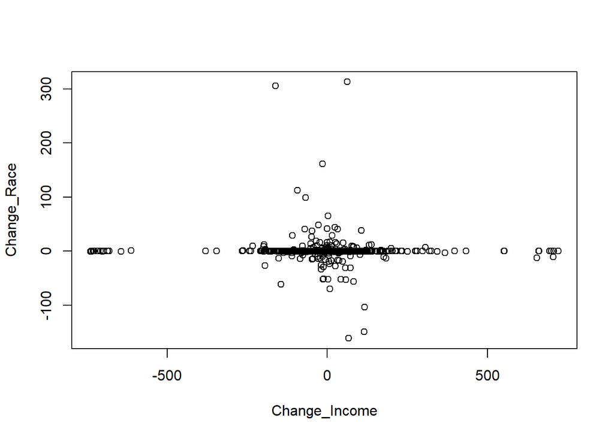

```r
plot(Change_Income,Change_Race)
```

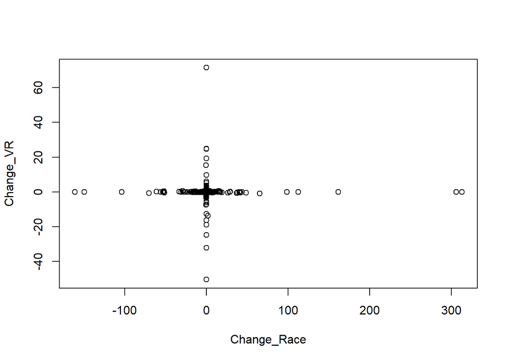

```r
plot(Change_Race,Change_VR)
```

# Conclusions

1. The result of income change show that most census block groups have slight and inconstant change. Even for a same census block group, the income could slightly rise up from 2013 to 2014, and slighty fall back from 2014 to 2015. In addtion, there is no significant pattern for the change distribution.
2. The change in vacancy rate and race ratio are even smaller than the change of income. Furthermore, the spatial distribution is chaotic.
3. No significant linear relationship among these three variables based on Pearson’s correlation test.
4. The results show no significant feedback in local society to the implementation of revitalization policy. The reason could be that the feedback need time to be present. Also, the reason could be that the data are collected from 5-year estimated ACS data, which is estimated based on previous five years survey data. The change could happen but not update in this dataset.

# References

Silverman, R., Yin, L., & Patterson, K. L. (2013). Dawn of the dead city: An exploratory analysis of vacant addresses in Buffalo, NY 2008-2010. Journal of Urban Affairs, 35(2), 131-152.

R Packages

https://cran.r-project.org/web/packages/tigris/tigris.pdf

https://cran.r-project.org/web/packages/censusapi/censusapi.pdf

Data source website

https://factfinder.census.gov/faces/nav/jsf/pages/searchresults.xhtml?refresh=t

Buffalo’s Comprehensive Plan

https://www.ci.buffalo.ny.us/files/1_2_1/Mayor/COB_Comprehensive_Plan/index.html

Buffalo’s Demolition Plan https://ppgbuffalo.org/files/documents/housing_neighborhoods/housing_conditions_and_repairs/housingneighborhoods-_buffalos_demolition_strategy.pdf